# PA1_template

# Q4: Are there differences in activity patterns between weekdays and weekends?

## For this part the weekdays() function may be of some help here.

## Use the dataset with the filled-in missing values for this part.

## Create a new factor variable in the dataset with two levels - “weekday” and “weekend”

## indicating whether a given date is a weekday or weekend day.

## Make a panel plot containing a time series plot (i.e. type = “l”)

## of the 5-minute interval (x-axis) and the average number of steps taken,

## averaged across all weekday days or weekend days (y-axis). See the README file in the GitHub repository to see an example of what this plot should look like using simulated data.

```r
data$date <- as.Date(data$date)
#create a vector of weekdays
step.weekday <- c('Monday', 'Tuesday', 'Wednesday', 'Thursday', 'Friday')

#Create a bew factor variable to specify the levels of week: weekday & weekend
data$flag_week <- factor((weekdays(data$date) %in% step.weekday),
                   levels=c(FALSE, TRUE), labels=c('Weekend', 'Weekday'))

avg.steps.week <- aggregate(steps ~ interval + flag_week, data=data, mean)
#checking...
```

```
#> head(avg.steps.week)
```

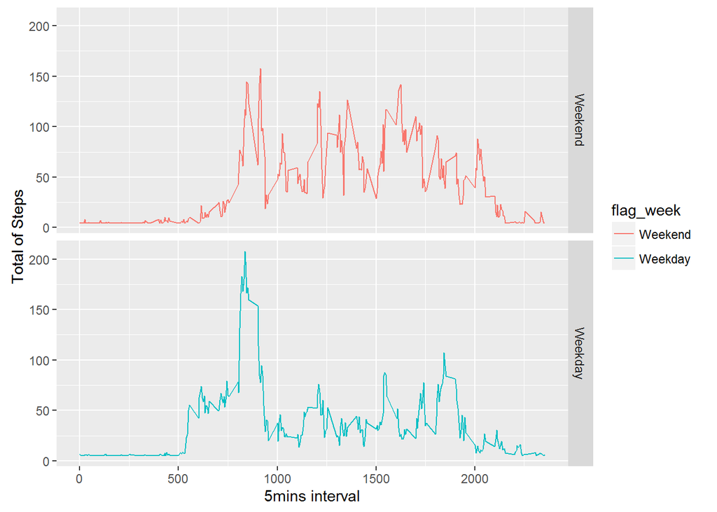

```r
#interval   flag_week    steps
#1        0   Weekend 4.672825
#2        5   Weekend 4.672825
#3       10   Weekend 4.672825
#4       15   Weekend 4.672825
#5       20   Weekend 4.672825
#6       25   Weekend 7.922825
##->> the output as shown above
## ------------------------------------------------------------------------
#avg.steps <- aggregate(steps ~ interval + day, data=filled.data, mean)

#prepare the .png file first
#png("avg5mins2.png", width=480, height=480)

#use ggplot to plot it beautifully
ggplot(avg.steps.week, aes(interval, steps)) +
  geom_line(aes(colour=flag_week, group=flag_week)) +
  facet_grid(flag_week ~ .) +
  xlab("5mins interval") +
  ylab("Total of Steps")
```